# stdin and stdout

sys.argv[0] and sys.argv[1] of the "egrep.py" file are described below.

egrep.py searches an input a user types at the commandline in a designated text file(=sys.stdin). It does so line by line: that's why the "egrep.py" file has a line that says

$"for{\ }line{\ }in{\ }sys.stdin"$

sys.stdin is used for all interactive input.

If regex, the variable for the typed input, is in a line, then that line will be written to stdout.

The '|' is the pipe character, which means "use the output of the left command as the input of the right command." Therefore, the output of the egrep.py command(lines that contain regex) will be the input of the line_count.py command.

line_count.py command does nothing but count every line that is contained in sys.stdin and print the sum total.

stdin is used for all interactive input (including calls to input()); stdout is used for the output of print() and expression statements and for the prompts of input() from: https://docs.python.org/3/library/sys.html

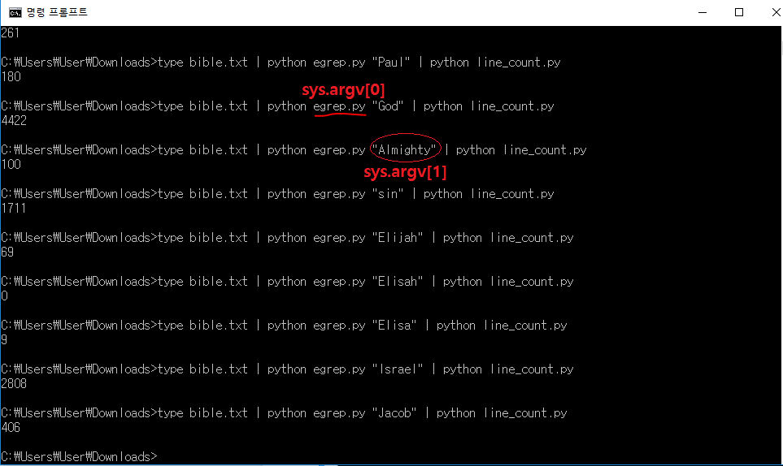

```python
# check what sys.argv[0] and sys.argv[1] are.
# each outcome tells how many lines include a sys.argv[1] user typed.
from IPython.display import Image
Image("C:/Users/User/Downloads/sample.png")
```

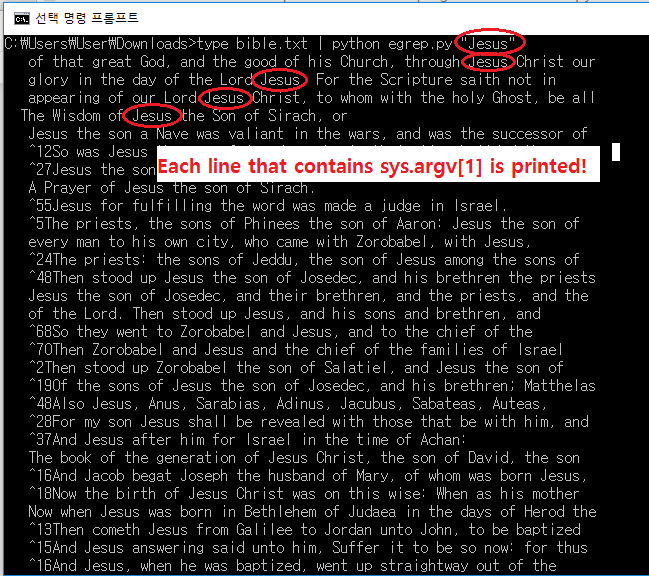

```python
# If egrep.py command is used alone, the outcome will be different
Image("C:/Users/User/Downloads/sample3.png")
```

```python
# most_common_words.py
import sys
from collections import Counter
# pass in number of words as first argument
try:
    num_words = int(sys.argv[1])
except:
    print "usage: most_common_words.py num_words"
    sys.exit(1) # non-zero exit code indicates error

counter = Counter(word.lower() # lowercase words
                  for line in sys.stdin #
                  for word in line.strip().split() # split on spaces
                  if word) # skip empty 'words'
for word, count in counter.most_common(num_words):
    sys.stdout.write(str(count))
    sys.stdout.write("\t")
    sys.stdout.write(word)
    sys.stdout.write("\n")
```

```
  File "<ipython-input-3-a595a194cf02>", line 8
    print "usage: most_common_words.py num_words"
                                                ^
SyntaxError: Missing parentheses in call to 'print'
```

```python
# str.strip([chars])
"""Return a copy of the string with the leading and trailing characters removed.
The chars argument is a string specifying the set of characters to be removed.
If omitted or None, the chars argument defaults to removing whitespace.
The chars argument is not a prefix or suffix;
rather, all combinations of its values are stripped"""

"hi hello      ".strip()
```

```
'hi hello'
```

```python
"www.naver.com".strip('cmowz.')
```

```
'naver'
```

```python
#str.split([chars])
"""Return a list of the words in the string, using sep as the delimiter string.
If maxsplit is given, at most maxsplit splits are done
(thus, the list will have at most maxsplit+1 elements).
If maxsplit is not specified or -1, then there is no limit on the number
of splits (all possible splits are made)."""

'1,2,3'.split(',')
```

```
['1', '2', '3']
```

```python
'1,2,3'.split(',', maxsplit=1)
```

```
['1', '2,3']
```

```python
'1 2 3'.split()
```

```
['1', '2', '3']
```

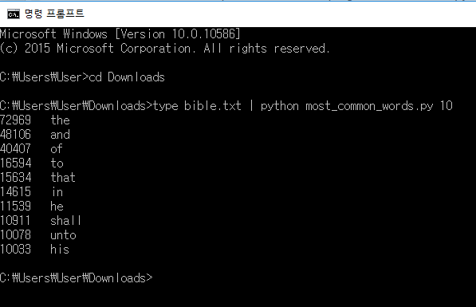

```python
# Check how you utilize most_common_words.py command
Image("C:/Users/User/Downloads/sample2.png")
```